# Informe Lab03

Marco Ramírez, Javier Hernandez

2023-03-12

# Laboratorio #3 – Clasificación de Malware

### Exploracion de datos e ingenieria de caracteristicas

```r
db<-read.csv('VirusSample.csv')
#Resumen de datos
summary(db)
```

```
##      file               api               class
##  Length:9795        Length:9795        Length:9795
##  Class :character   Class :character   Class :character
##  Mode  :character   Mode  :character   Mode  :character
```

```r
#Las primeros 5 filas
head(db,5)
```

```
##                                       file
## 1 7ff49f2f0912352416b05c010f35f402cc79feed
## 2 50cc6c99ec285d0db45dde07d8fdc18d9098c5b6
## 3 f77c6bd4aebacd1a01d02e0cb20642ebf2d32929
## 4 349c367c5b88fbb6cafae5d7109588d7250e16b5
## 5 021f4aa86b520e1d606ab26699c35546bcd00c27
##                                                                                                                   api
## 1                                                                          IntersectRect,GetCurrentProcess,GetVersion
## 2                                          GetCaretBlinkTime,CountClipboardFormats,GetConsoleWindow,GetCurrentProcess
## 3                                                      VarR8Pow,GetClipboardViewer,GetInputDesktop,GetUserDefaultLCID
## 4                           SetTraceCallback,CopyAcceleratorTableW,GetProcessHeap,GetSystemDefaultLangID,GetLastError
## 5 SHLoadNonloadedIconOverlayIdentifiers,VarUI8FromDisp,GetSystemRegistryQuota,GetConsoleWindow,GetOpenClipboardWindow
##   class
## 1 Virus
## 2 Virus
## 3 Virus
## 4 Virus
## 5 Virus
```

```r
#Cantidad de columnas
ncol(db)
```

```
## [1] 3
```

```r
#Cantidad de filas
nrow(db)
```

```
## [1] 9795
```

Como se logra observar la base de datos ‘VirusSample.csv’ tiene 3 columnas y *9795* filas.

Como parte importante para poder clasificar los tipos de virus, se requiere verificar la cantidad de datos de cada uno.

```r
table(db$class)
```

```
##
##     Adware      Agent   Backdoor      Crypt Downloader    Dropper  Keylogger
##        222        102        447          2         31          4          1
## Ransomware   Riskware    Spyware     Trojan      Virus      Worms
##         10          4         11       6153       2367        441
```

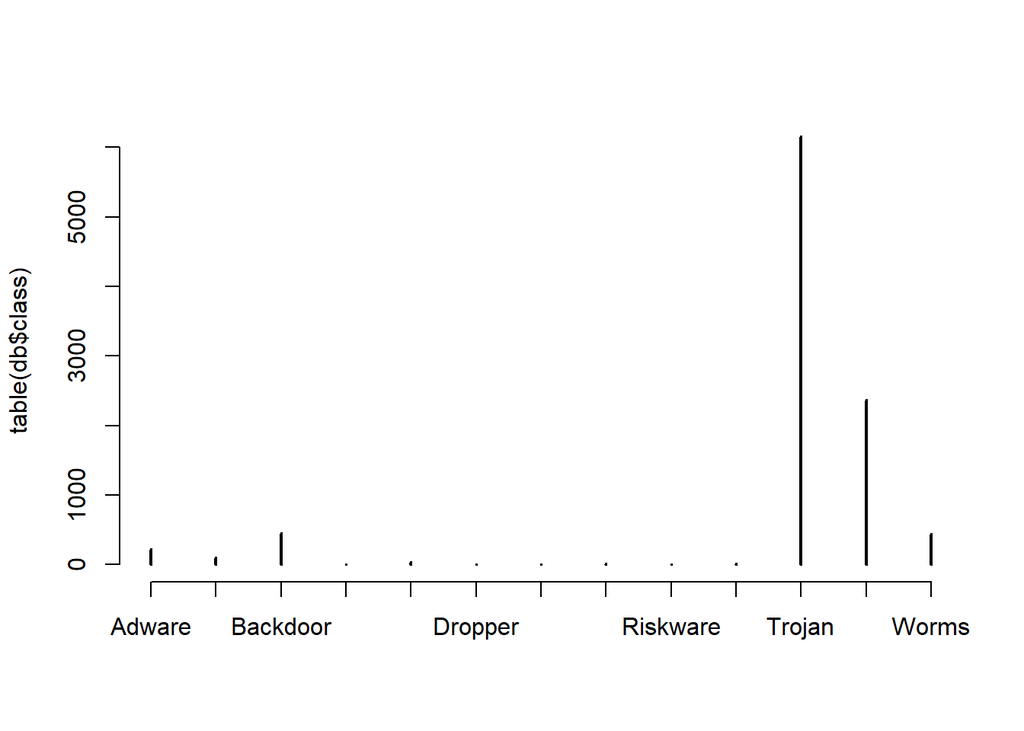

```r
plot(table(db$class))
```

Como se observa los tipos de virus no se encuentran balanceados, sin embargo, si los balanceamos tendriamos como minimo 1 tipo de virus por categoria, por ende, seguiremos trabajando de esta manera.

Tambien podemos ver las APIS mas repetidas en el dataset:

```r
library("RColorBrewer")
library("syuzhet")
library("ggplot2")
library("SnowballC")
library("wordcloud")
library("tm")

db$api<-gsub(",", " ", db$api)

TextDoc <- Corpus(VectorSource(db$api))
toSpace <- content_transformer(function (x , pattern ) gsub(pattern, " ", x))
TextDoc <- tm_map(TextDoc, content_transformer(tolower))
TextDoc_dtm <- TermDocumentMatrix(TextDoc)
dtm_m <- as.matrix(TextDoc_dtm)
# Sort by descearing value of frequency
dtm_v <- sort(rowSums(dtm_m),decreasing=TRUE)
dtm_d <- data.frame(word = names(dtm_v),freq=dtm_v)
# Display the top 5 most frequent words
(dtm_d[1:10,])
```

```
##                                  word freq
## getprocaddress         getprocaddress 6066
## loadlibrarya             loadlibrarya 5130
## exitprocess               exitprocess 4882
## getmodulehandlea     getmodulehandlea 3891
## virtualalloc             virtualalloc 2851
## closehandle               closehandle 2836
## virtualfree               virtualfree 2763
## getcurrentthreadid getcurrentthreadid 2425
## writefile                   writefile 2338
## readfile                     readfile 2319
```

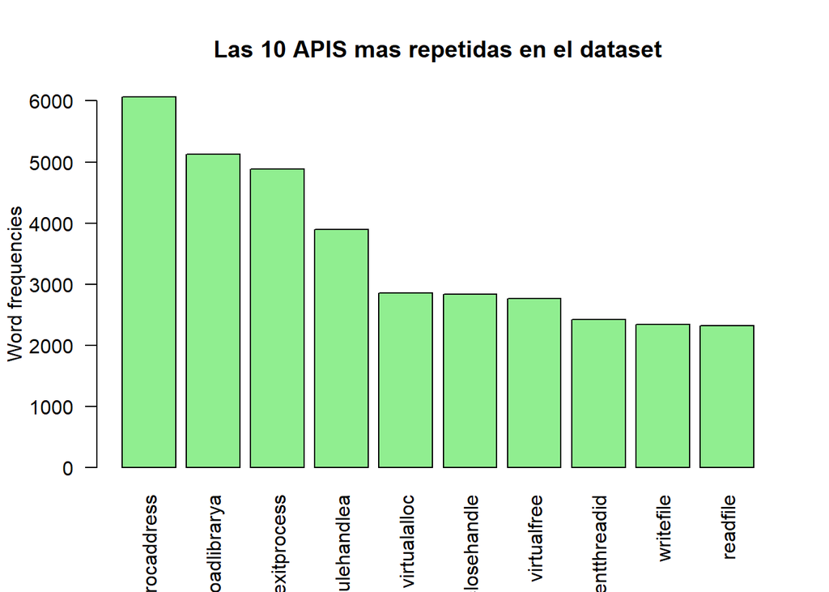

```r
barplot(dtm_d[1:10,]$freq, las = 2, names.arg = dtm_d[1:10,]$word,
        col ="lightgreen", main ="Las 10 APIS mas repetidas en el dataset",
        ylab = "Word frequencies")
```

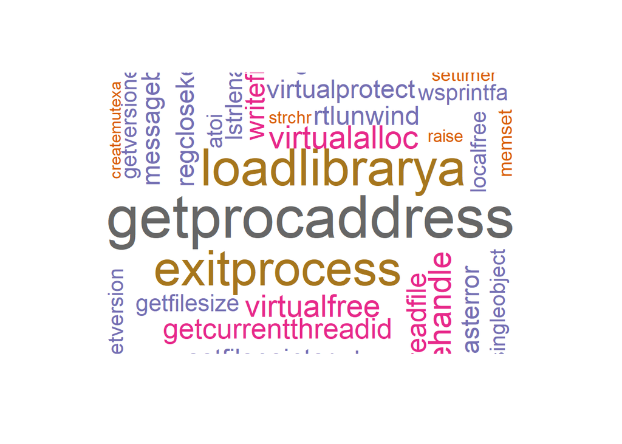

```r
set.seed(1234)
wordcloud(words = dtm_d$word, freq = dtm_d$freq, min.freq = 5,
          max.words=100, random.order=FALSE, rot.per=0.40,
          colors=brewer.pal(8, "Dark2"))
```

### Preprocesamiento

Como se observo anteriormente los datos no se encuentran balanceados, por ende se requiere balancearlos. Sin embargo, las siguientes variables contienen muy pocos datos por lo cual se decidio juntarlos. Siendo Crypt, Downloader, Dropper, Keylogger, Ransomware, Riskware y Spyware.

```r
db<-read.csv('VirusSample.csv')
table(db$class)
```

```
##
##     Adware      Agent   Backdoor      Crypt Downloader    Dropper  Keylogger
##        222        102        447          2         31          4          1
## Ransomware   Riskware    Spyware     Trojan      Virus      Worms
##         10          4         11       6153       2367        441
```

```r
db$class[db$class=='Crypt'|db$class=='Downloader' |db$class=='Dropper' |  db$class=='Keylogger'| db$class=='Ransomware'|db$class=='Riskware'| db$class=='Spyware'] <- 'Otro'

table(db$class)
```

```
##
##   Adware    Agent Backdoor     Otro   Trojan    Virus    Worms
##      222      102      447       63     6153     2367      441
```

### Implementacion

#### SVM

```r
#Importamos las librerias necesarias
library(e1071)
library(caret)

db$class<-as.factor(db$class)
db$file<-as.factor(db$file)
db$api<-as.factor(db$api)
#SVM
#Indicamos el porcentaje de entranamiento
porcentaje<-0.7

#Datos de entrenamiento y prueba
corte <- sample(nrow(db),nrow(db)*porcentaje)
train<-db[corte,]
test<-db[-corte,]

#Como tenemos muy pocos datos de spyware
#Creamos el modelo
modelosvm<-svm(class~., data = train, scale = F)
summary(modelosvm)
```

```
##
## Call:
## svm(formula = class ~ ., data = train, scale = F)
##
##
## Parameters:
##    SVM-Type:  C-classification
##  SVM-Kernel:  radial
##        cost:  1
##
## Number of Support Vectors:  4211
##
##  ( 1667 298 1655 312 159 44 76 )
##
##
## Number of Classes:  7
##
## Levels:
##  Adware Agent Backdoor Otro Trojan Virus Worms
```

#### Random Forest

```r
#Importamos las librerias necesarias
library(randomForest)
library(forcats)

#Modificamos la data
new_db <- db[, c("api","class")]
new_db$new_api <- fct_lump(new_db$api, n = 50, other_level = "Otros")
head(new_db, 5)
```

```
##                                                                                                                   api
## 1                                                                          IntersectRect,GetCurrentProcess,GetVersion
## 2                                          GetCaretBlinkTime,CountClipboardFormats,GetConsoleWindow,GetCurrentProcess
## 3                                                      VarR8Pow,GetClipboardViewer,GetInputDesktop,GetUserDefaultLCID
## 4                           SetTraceCallback,CopyAcceleratorTableW,GetProcessHeap,GetSystemDefaultLangID,GetLastError
## 5 SHLoadNonloadedIconOverlayIdentifiers,VarUI8FromDisp,GetSystemRegistryQuota,GetConsoleWindow,GetOpenClipboardWindow
##   class new_api
## 1 Virus   Otros
## 2 Virus   Otros
## 3 Virus   Otros
## 4 Virus   Otros
## 5 Virus   Otros
```

```r
summary(new_db)
```

```
##                                                                                                                                                                                                                                                                                                          …
##  LoadLibraryA,GetProcAddress                                                                                                                                                                                                                                                                             …
##  LoadLibraryA,GetProcAddress,VirtualProtect,VirtualAlloc,VirtualFree,ExitProcess,atoi,PathFileExistsA,wsprintfA                                                                                                                                                                                          …
##  MessageBoxA,wsprintfA,ExitProcess,GetModuleHandleA,GetProcAddress,VirtualProtect,VirtualAlloc,VirtualFree,LoadLibraryA                                                                                                                                                                                  …
##  MethCallEngine,EVENT_SINK_AddRef,DllFunctionCall,EVENT_SINK_Release,EVENT_SINK_QueryInterface,__vbaExceptHandler,ProcCallEngine                                                                                                                                                                         …
##  GetModuleHandleA,GetProcAddress,fabs,InitCommonControls,IsChild,BitBlt,CoInitialize,ShellExecuteExA,PathQuoteSpacesA                                                                                                                                                                                    …
##  WSAGetLastError,WSAStartup,__WSAFDIsSet,accept,bind,closesocket,connect,gethostbyname,htonl,htons,inet_addr,ioctlsocket,listen,recv,select,send,socket,CoCreateInstance,CLSIDFromString,CoTaskMemFree,CoInitialize,CoUninitialize,SysAllocString,DeleteUrlCacheEntry,FindFirstUrlCacheEntryA,FindNextUrl…
##  (Other)                                                                                                                                                                                                                                                                                                 …
##       class
##  Adware  : 222
##  Agent   : 102
##  Backdoor: 447
##  Otro    :  63
##  Trojan  :6153
##  Virus   :2367
##  Worms   : 441
##                                                                                                                             new_api
##  Otros                                                                                                                          :3374
##  LoadLibraryA,GetProcAddress                                                                                                    :1007
##  LoadLibraryA,GetProcAddress,VirtualProtect,VirtualAlloc,VirtualFree,ExitProcess,atoi,PathFileExistsA,wsprintfA                 : 830
##  MessageBoxA,wsprintfA,ExitProcess,GetModuleHandleA,GetProcAddress,VirtualProtect,VirtualAlloc,VirtualFree,LoadLibraryA         : 544
##  MethCallEngine,EVENT_SINK_AddRef,DllFunctionCall,EVENT_SINK_Release,EVENT_SINK_QueryInterface,__vbaExceptHandler,ProcCallEngine: 519
##  GetModuleHandleA,GetProcAddress,fabs,InitCommonControls,IsChild,BitBlt,CoInitialize,ShellExecuteExA,PathQuoteSpacesA           : 382
##  (Other)                                                                                                                        :3139
```

```r
#Indicamos el porcentaje de entranamiento
porcentaje<-0.7

#Datos de entrenamiento y prueba
corte2 <- sample(nrow(new_db),nrow(new_db)*porcentaje)
train2<-new_db[corte2,]
test2<-new_db[-corte2,]

#Creamos el modelo
#modelosvm<-svm(class~., data = train, scale = F)
#summary(modelosvm)
modelo_rf <- randomForest(class ~ new_api, data = train2, ntree = 500)
print(modelo_rf)
```

```
##
## Call:
##  randomForest(formula = class ~ new_api, data = train2, ntree = 500)
##                Type of random forest: classification
##                      Number of trees: 500
## No. of variables tried at each split: 1
##
##         OOB estimate of  error rate: 13.74%
## Confusion matrix:
##          Adware Agent Backdoor Otro Trojan Virus Worms class.error
## Adware       89     0        0    0      9    71     0   0.4733728
## Agent         0     0        0    0     60    12     0   1.0000000
## Backdoor      0     0      301    0     24    11     0   0.1041667
## Otro          4     0        0    0      1    39     0   1.0000000
## Trojan        0     0        0    0   3782   508    18   0.1220984
## Virus         0     0        0    0     30  1589     1   0.0191358
## Worms         0     0        0    0     68    86   153   0.5016287
```

```r
#Mostrar el arbol generado por el modelo
#library(rpart.plot)
#attach(train2)

#Obtener árbol del modelo
#arbol_rf <- randomForest::getTree(modelo_rf, k = 1)

#Convertir el árbol de randomForest en un objeto rpart
#arbol_rpart <- rpart::rpart(
#  formula = formula(modelo_rf),
#  data = modelo_rf$forest$x,
#  method = "class",
#  control = rpart::rpart.control(cp = 0.001)
#)

#Graficar el árbol con rpart.plot
#rpart.plot::rpart.plot(
#  arbol_rpart,
#  extra = 1,
#  under = TRUE,
#  box.palette = "Greens",
#  branch.lty = 3,
#  nn = TRUE
#)

#m1<-rpart(class ~ ., data = train2)
#rpart.plot(m1, type = 3, digits = 3, fallen.leaves = TRUE)
```

Se puede observar que el modelo fue creado de manera correcta y que tiene una estimación OOB de la tasa de error de un 13.74%. Esto significa que ese porcentaje es el porcentaje de error o de equivocación del método OBB que evalua la precisión del modelo, y es bueno ya que es un porcentaje bajo.

### Precision de los modelos

#### SVM

```r
#Modelos
#SVM
predi<-predict(modelosvm,test[,1:2])
confusionMatrix(test$class,predi)
```

```
## Confusion Matrix and Statistics
##
##           Reference
## Prediction Adware Agent Backdoor Otro Trojan Virus Worms
##   Adware        0     0        0    0     63     0     0
##   Agent         0     0        0    0     26     0     0
##   Backdoor      0     0        0    0    149     0     0
##   Otro          0     0        0    0     19     0     0
##   Trojan        0     0        0    0   1841     0     0
##   Virus         0     0        0    0    712     0     0
##   Worms         0     0        0    0    129     0     0
##
## Overall Statistics
##
##                Accuracy : 0.6264
##                  95% CI : (0.6086, 0.6439)
##     No Information Rate : 1
##     P-Value [Acc > NIR] : 1
##
##                   Kappa : 0
##
##  Mcnemar's Test P-Value : NA
##
## Statistics by Class:
##
##                      Class: Adware Class: Agent Class: Backdoor Class: Otro
## Sensitivity                     NA           NA              NA          NA
## Specificity                0.97856     0.991153          0.9493    0.993535
## Pos Pred Value                  NA           NA              NA          NA
## Neg Pred Value                  NA           NA              NA          NA
## Prevalence                 0.00000     0.000000          0.0000    0.000000
## Detection Rate             0.00000     0.000000          0.0000    0.000000
## Detection Prevalence       0.02144     0.008847          0.0507    0.006465
## Balanced Accuracy               NA           NA              NA          NA
##                      Class: Trojan Class: Virus Class: Worms
## Sensitivity                 0.6264           NA           NA
## Specificity                     NA       0.7577      0.95611
## Pos Pred Value                  NA           NA           NA
## Neg Pred Value                  NA           NA           NA
## Prevalence                  1.0000       0.0000      0.00000
## Detection Rate              0.6264       0.0000      0.00000
## Detection Prevalence        0.6264       0.2423      0.04389
## Balanced Accuracy               NA           NA           NA
```

Se observa que el primer modelo tiene un accuracy o una exactitud de 0.6264 lo que significa que el 62.64% de los datos arrojados por la matriz son cercanos o idénticos a los datos reales.

Además, la mayoría de clases tienen un specificity o especificidad mayor a 0.94, lo que significa que el modelo acierta más del 94% de los casos negativos. Es decir, esta métrica pone en relación la cantidad de casos negativos detectados con la cantidad de casos negativos totales.

#### Random Forest

```r
predi2<-predict(modelo_rf,test2[,1:3])
confusionMatrix(test2$class,predi2)
```

```
## Confusion Matrix and Statistics
##
##           Reference
## Prediction Adware Agent Backdoor Otro Trojan Virus Worms
##   Adware       28     0        0    0      1    24     0
##   Agent         0     0        0    0     20    10     0
##   Backdoor      0     0       89    0     16     6     0
##   Otro          2     0        0    0      1    16     0
##   Trojan        1     0        0    0   1604   230    10
##   Virus         0     0        0    0     14   733     0
##   Worms         0     0        0    0     30    39    65
##
## Overall Statistics
##
##                Accuracy : 0.8571
##                  95% CI : (0.8439, 0.8696)
##     No Information Rate : 0.5737
##     P-Value [Acc > NIR] : < 2.2e-16
##
##                   Kappa : 0.7382
##
##  Mcnemar's Test P-Value : NA
##
## Statistics by Class:
##
##                      Class: Adware Class: Agent Class: Backdoor Class: Otro
## Sensitivity               0.903226           NA         1.00000          NA
## Specificity               0.991403      0.98979         0.99228    0.993535
## Pos Pred Value            0.528302           NA         0.80180          NA
## Neg Pred Value            0.998960           NA         1.00000          NA
## Prevalence                0.010548      0.00000         0.03028    0.000000
## Detection Rate            0.009527      0.00000         0.03028    0.000000
## Detection Prevalence      0.018033      0.01021         0.03777    0.006465
## Balanced Accuracy         0.947314           NA         0.99614          NA
##                      Class: Trojan Class: Virus Class: Worms
## Sensitivity                 0.9514       0.6928      0.86667
## Specificity                 0.8077       0.9926      0.97591
## Pos Pred Value              0.8694       0.9813      0.48507
## Neg Pred Value              0.9250       0.8517      0.99643
## Prevalence                  0.5737       0.3600      0.02552
## Detection Rate              0.5458       0.2494      0.02212
## Detection Prevalence        0.6278       0.2542      0.04559
## Balanced Accuracy           0.8795       0.8427      0.92129
```

Se observa que el segundo modelo tiene un accuracy o una exactitud de 0.8571 lo que significa que el 85.71% de los datos arrojados por la matriz son cercanos o idénticos a los datos reales.

Además, la mayoría de clases tienen un sensitivity o sensibilidad mayor a 0.86, esto quiere decir que el modelo acierta más del 86% de los casos positivos. Es decir, esta métrica determina la capacidad del algoritmo de detectar los casos positivos.

También, la mayoría de clases tienen un specificity o especificidad mayor a 0.97, por lo que sabemos que el modelo acierta más del 97% de los casos negativos. Y por último, la mayoría de clases tienen un balanced accuracy o exactitud equilibrada mayor a 0.84.